# hw_4_MGanbold

Ganbold,MungunSarnai

10/27/2019

# Homework question 1.

##Data

Feature selection methods from the lab on another UCI derived breast cancer dataset with other variables related to parameters of nucleoli from fine niddle aspiration technique. Features were already calculated from digital images, of course :)

```r
#Loading and preparing data:
brca <- read.csv("/Users/mungunsarnaiganbold/Desktop/ML_2019/hw4-MSGanbold/data.csv")
str(brca)
```

```
## 'data.frame':    569 obs. of  33 variables:
##  $ id                     : int  842302 842517 84300903 84348301 84358402 843786 844359 84458202 844981 84501001 ...
##  $ diagnosis              : Factor w/ 2 levels "B","M": 2 2 2 2 2 2 2 2 2 2 ...
##  $ radius_mean            : num  18 20.6 19.7 11.4 20.3 ...
##  $ texture_mean           : num  10.4 17.8 21.2 20.4 14.3 ...
##  $ perimeter_mean         : num  122.8 132.9 130 77.6 135.1 ...
##  $ area_mean              : num  1001 1326 1203 386 1297 ...
##  $ smoothness_mean        : num  0.1184 0.0847 0.1096 0.1425 0.1003 ...
##  $ compactness_mean       : num  0.2776 0.0786 0.1599 0.2839 0.1328 ...
##  $ concavity_mean         : num  0.3001 0.0869 0.1974 0.2414 0.198 ...
##  $ concave.points_mean    : num  0.1471 0.0702 0.1279 0.1052 0.1043 ...
##  $ symmetry_mean          : num  0.242 0.181 0.207 0.26 0.181 ...
##  $ fractal_dimension_mean : num  0.0787 0.0567 0.06 0.0974 0.0588 ...
##  $ radius_se              : num  1.095 0.543 0.746 0.496 0.757 ...
##  $ texture_se             : num  0.905 0.734 0.787 1.156 0.781 ...
```

[output cut: 19 more lines]

```r
#all predictors are numeric
summary(is.na(brca))
```

```
##      id          diagnosis       radius_mean     texture_mean
##  Mode :logical   Mode :logical   Mode :logical   Mode :logical
##  FALSE:569       FALSE:569       FALSE:569       FALSE:569
##  perimeter_mean  area_mean       smoothness_mean compactness_mean
##  Mode :logical   Mode :logical   Mode :logical   Mode :logical
##  FALSE:569       FALSE:569       FALSE:569       FALSE:569
##  concavity_mean  concave.points_mean symmetry_mean
##  Mode :logical   Mode :logical       Mode :logical
##  FALSE:569       FALSE:569           FALSE:569
##  fractal_dimension_mean radius_se       texture_se      perimeter_se
##  Mode :logical          Mode :logical   Mode :logical   Mode :logical
##  FALSE:569              FALSE:569       FALSE:569       FALSE:569
##   area_se        smoothness_se   compactness_se  concavity_se
##  Mode :logical   Mode :logical   Mode :logical   Mode :logical
##  FALSE:569       FALSE:569       FALSE:569       FALSE:569
##  concave.points_se symmetry_se     fractal_dimension_se radius_worst
##  Mode :logical     Mode :logical   Mode :logical        Mode :logical
##  FALSE:569         FALSE:569       FALSE:569            FALSE:569
##  texture_worst   perimeter_worst area_worst      smoothness_worst
##  Mode :logical   Mode :logical   Mode :logical   Mode :logical
##  FALSE:569       FALSE:569       FALSE:569       FALSE:569
##  compactness_worst concavity_worst concave.points_worst symmetry_worst
##  Mode :logical     Mode :logical   Mode :logical        Mode :logical
##  FALSE:569         FALSE:569       FALSE:569            FALSE:569
##  fractal_dimension_worst    X
##  Mode :logical           Mode:logical
##  FALSE:569               TRUE:569
```

```r
#all NAs are in a last column "X"
#removing ID and X columns:
brca <- brca[, -c(1, 33)]
head(brca)
```

```
##   diagnosis radius_mean texture_mean perimeter_mean area_mean
## 1         M       17.99        10.38         122.80    1001.0
## 2         M       20.57        17.77         132.90    1326.0
## 3         M       19.69        21.25         130.00    1203.0
## 4         M       11.42        20.38          77.58     386.1
## 5         M       20.29        14.34         135.10    1297.0
## 6         M       12.45        15.70          82.57     477.1
##   smoothness_mean compactness_mean concavity_mean concave.points_mean
## 1         0.11840          0.27760         0.3001             0.14710
## 2         0.08474          0.07864         0.0869             0.07017
## 3         0.10960          0.15990         0.1974             0.12790
## 4         0.14250          0.28390         0.2414             0.10520
## 5         0.10030          0.13280         0.1980             0.10430
## 6         0.12780          0.17000         0.1578             0.08089
##   symmetry_mean fractal_dimension_mean radius_se texture_se perimeter_se
```

[output cut: 41 more lines]

##Feature selection based on stat.scores (Pearson correlation):

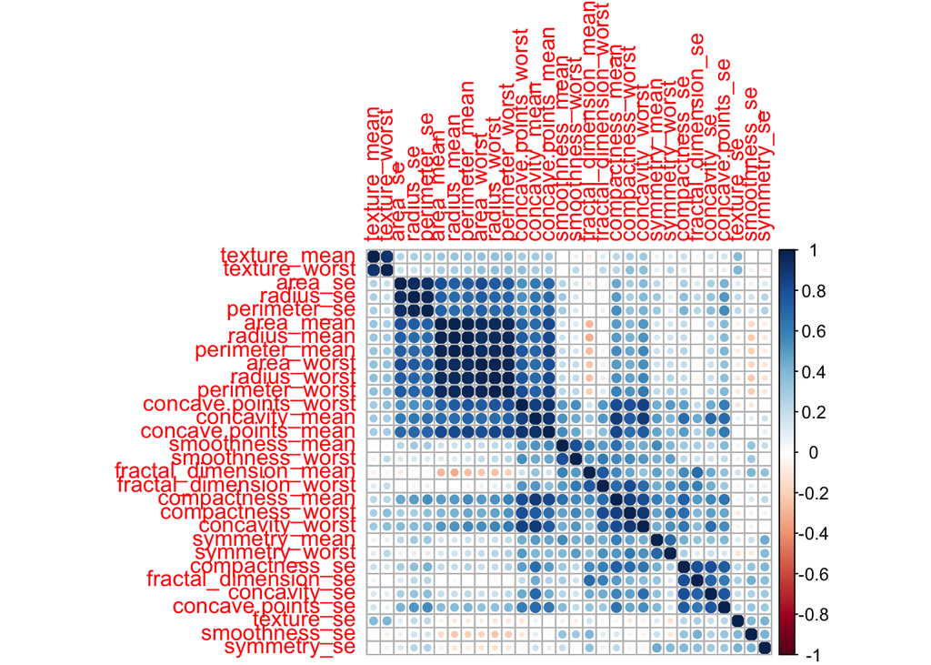

```r
library(corrplot)
corMatrix = cor(brca[,2:31])
corrplot(corMatrix, order = "hclust")
```

```r
#correlation filter=0.7
highly_correlated <- colnames(brca[, -1])[findCorrelation(corMatrix, cutoff = 0.7, verbose = TRUE)]
```

```
## Compare row 7  and column  8 with corr  0.921
##   Means:  0.571 vs 0.389 so flagging column 7
## Compare row 8  and column  6 with corr  0.831
##   Means:  0.542 vs 0.377 so flagging column 8
## Compare row 6  and column  28 with corr  0.816
##   Means:  0.524 vs 0.365 so flagging column 6
## Compare row 28  and column  27 with corr  0.855
##   Means:  0.507 vs 0.354 so flagging column 28
## Compare row 27  and column  26 with corr  0.892
##   Means:  0.457 vs 0.343 so flagging column 27
## Compare row 23  and column  21 with corr  0.994
##   Means:  0.456 vs 0.333 so flagging column 23
## Compare row 21  and column  3 with corr  0.969
##   Means:  0.422 vs 0.324 so flagging column 21
## Compare row 3  and column  24 with corr  0.942
##   Means:  0.384 vs 0.316 so flagging column 3
## Compare row 26  and column  30 with corr  0.81
##   Means:  0.4 vs 0.313 so flagging column 26
## Compare row 24  and column  1 with corr  0.941
##   Means:  0.356 vs 0.302 so flagging column 24
## Compare row 1  and column  4 with corr  0.987
##   Means:  0.308 vs 0.298 so flagging column 1
## Compare row 4  and column  13 with corr  0.727
##   Means:  0.27 vs 0.294 so flagging column 13
## Compare row 4  and column  11 with corr  0.733
##   Means:  0.244 vs 0.29 so flagging column 11
## Compare row 4  and column  14 with corr  0.8
##   Means:  0.213 vs 0.294 so flagging column 14
## Compare row 18  and column  16 with corr  0.744
##   Means:  0.36 vs 0.292 so flagging column 18
## Compare row 16  and column  17 with corr  0.801
##   Means:  0.394 vs 0.288 so flagging column 16
## Compare row 17  and column  20 with corr  0.727
##   Means:  0.292 vs 0.272 so flagging column 17
## Compare row 5  and column  25 with corr  0.805
##   Means:  0.33 vs 0.268 so flagging column 5
## Compare row 10  and column  30 with corr  0.767
##   Means:  0.372 vs 0.256 so flagging column 10
## Compare row 22  and column  2 with corr  0.912
##   Means:  0.253 vs 0.243 so flagging column 22
## All correlations <= 0.7
```

```r
#these features are highly correlated and can be removed later to improve the accuracy of a model:
highly_correlated
```

```
##  [1] "concavity_mean"         "concave.points_mean"
##  [3] "compactness_mean"       "concave.points_worst"
##  [5] "concavity_worst"        "perimeter_worst"
##  [7] "radius_worst"           "perimeter_mean"
##  [9] "compactness_worst"      "area_worst"
## [11] "radius_mean"            "perimeter_se"
## [13] "radius_se"              "concave.points_se"
## [15] "compactness_se"         "area_se"
## [17] "concavity_se"           "smoothness_mean"
## [19] "fractal_dimension_mean" "texture_worst"
```

```r
#20 features out of 30
```

##Machine learning algorithm based Recursive Feature Elimination (wrapper) method:

```r
#defining a helper function from pickSizeBest{caret} for backwards feature selection:
control = rfeControl(functions = caretFuncs, number = 2)
#number =list of options incl functions for fitting n prediction

# RFE with svmRadial:
results = rfe(brca[,2:31], brca[,1], sizes = c(10,20,30), rfeControl = control, method = "svmRadial")
#tries first 10, then 20 and lastly all 30 features
results
```

```
##
## Recursive feature selection
##
## Outer resampling method: Bootstrapped (2 reps)
##
## Resampling performance over subset size:
##
##  Variables Accuracy  Kappa AccuracySD  KappaSD Selected
##         10   0.9425 0.8801   0.003470 0.008527
##         20   0.9760 0.9498   0.001385 0.002489
##         30   0.9762 0.9501   0.005409 0.011848        *
##
## The top 5 variables (out of 30):
##    perimeter_worst, area_worst, radius_worst, concave.points_worst, concave.points_mean
```

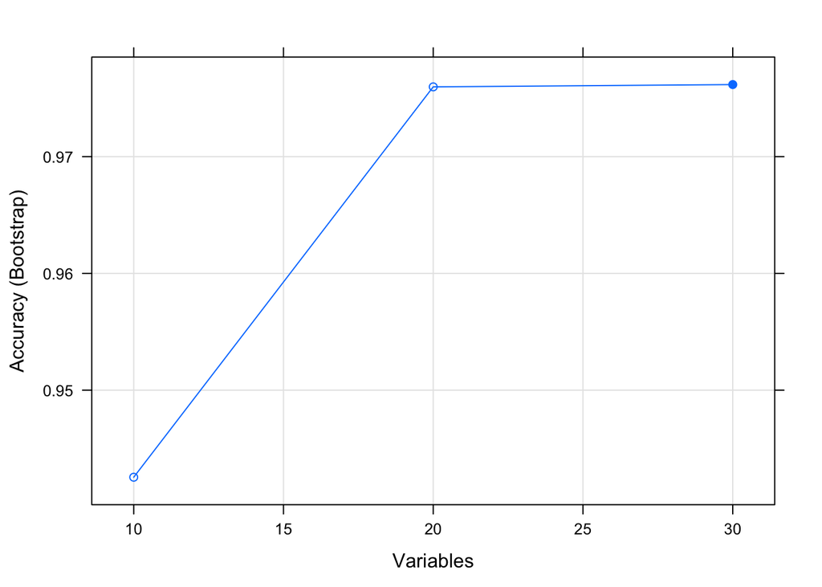

```r
#results$variables

plot(results, type=c("g","o"))
```

RFE with svmRadial model Accuracy with different set of features.

##Imbedded penalizing LASSO feature selection method with Logistic Regression:

```r
set.seed(24)

#convert data
x = as.matrix(brca[,2:31]) #predictors
y = as.double(as.matrix(ifelse(brca[,1]=='B', 0, 1)))
#y=double precision vector (floating point number)
#target is factored

#Logistic regression with LASSO (alpha=1):
cv.lasso <- cv.glmnet(x, y, family='binomial', alpha=1, parallel=TRUE, standardize=TRUE, type.measure='auc')
```

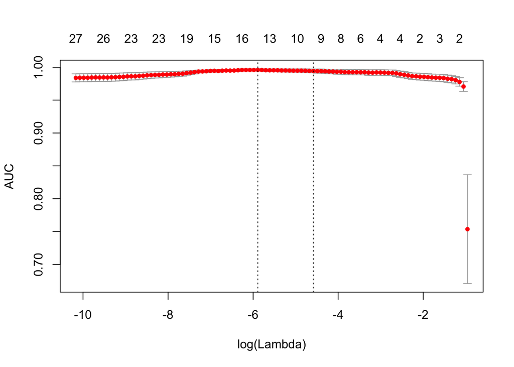

```r
#cv.glmnet(x, y, weights, offset, lambda, type.measure, nfolds, foldid, alignment,
#     grouped, keep, parallel, ...)

#plot accuracy of LG with LASSO:
plot(cv.lasso)
```

```r
cat('Min Lambda: ', cv.lasso$lambda.min, '\n 1Sd Lambda: ', cv.lasso$lambda.1se)
```

```
## Min Lambda:  0.002770503
##  1Sd Lambda:  0.01019096
```

```r
#cat{base} - concatinate the above columns and print them under: Min Lambda and 1Sd Lambda

#lambda.min for each feature:
df_lambda_min <- round(as.matrix(coef(cv.lasso, s=cv.lasso$lambda.min)), 2)

# See all contributing variables
df_lambda_min[df_lambda_min[, 1] != 0, ]
```

```
##            (Intercept)           texture_mean         concavity_mean
##                 -30.43                   0.04                   0.68
##    concave.points_mean fractal_dimension_mean              radius_se
##                  21.22                 -17.38                   7.63
##             texture_se          smoothness_se         compactness_se
##                  -0.15                  52.03                 -30.93
##   fractal_dimension_se           radius_worst          texture_worst
##                 -79.45                   0.80                   0.21
##       smoothness_worst        concavity_worst   concave.points_worst
##                  25.25                   4.30                  18.13
##         symmetry_worst
##                   7.41
```

```r
#subset all variables from coef column that are not equal to 0
```

##Random Forest with its importance weight as an imbedded feature selection method.

```r
data(brca)
train_size <- floor(0.80 * nrow(brca))
set.seed(7)
train_Id <- sample(seq_len(nrow(brca)), size = train_size)
#train indices by rows

# all features are already numeric and data is clean

train_brca <- brca[train_Id, ] #values
test_brca <- brca[-train_Id, ]
dim(train_brca)
```

```
## [1] 455  31
```

```r
dim(test_brca)
```

```
## [1] 114  31
```

```r
#RF:
random_forest = randomForest(diagnosis ~., data=train_brca, importance = TRUE, oob.times = 15, confusion = TRUE)
random_forest
```

```
##
## Call:
##  randomForest(formula = diagnosis ~ ., data = train_brca, importance = TRUE,      oob.times = 15, confusion = TRUE)
##                Type of random forest: classification
##                      Number of trees: 500
## No. of variables tried at each split: 5
##
##         OOB estimate of  error rate: 3.52%
## Confusion matrix:
##     B   M class.error
## B 279   7  0.02447552
## M   9 160  0.05325444
```

```r
#importance function gives ranking of features in RF model:
#importance(random_forest)
importance(random_forest, type=1)
```

```
##                         MeanDecreaseAccuracy
## radius_mean                        8.7797662
## texture_mean                       9.8413808
## perimeter_mean                     9.5930933
## area_mean                         11.3540399
## smoothness_mean                    6.2306140
## compactness_mean                   5.5737363
## concavity_mean                    10.2803521
## concave.points_mean               15.0664966
## symmetry_mean                      1.5788661
## fractal_dimension_mean             3.5566361
## radius_se                          9.3934893
## texture_se                         0.3974938
## perimeter_se                       8.3182832
## area_se                           14.0137363
## smoothness_se                      1.2544229
## compactness_se                     4.7284885
## concavity_se                       5.2610180
## concave.points_se                  4.3904007
## symmetry_se                        0.7652464
## fractal_dimension_se               1.8183782
## radius_worst                      16.4985758
## texture_worst                     10.9598822
## perimeter_worst                   15.8003020
## area_worst                        17.2665847
## smoothness_worst                   9.3911705
## compactness_worst                  6.8554450
## concavity_worst                   11.6885337
## concave.points_worst              18.8090024
## symmetry_worst                     7.8983447
## fractal_dimension_worst            5.1428352
```

```r
#"type" of importance measure (1=mean decrease in ACCURACY, 2=mean decrease in node impurity).
#"class" for classification problem, which class-specific measure to return.
#"scale" for permutation based measures, should the measures be divided their “standard errors”?
```

#Homework Question 2. Attempt a feature selection method not covered in this tutorial (backward elimination, forward propogation, etc.)

##We will try Simulated Annealing method.

Simulated annealing is a global search algorithm that allows a suboptimal solution to be accepted in hope that a better solution will show up eventually.

It works by making small random changes to an initial solution and sees if the performance improved. The change is accepted if it improves, else it can still be accepted if the difference of performances meet an acceptance criteria.

In caret, it has been implemented in the safs(). It accepts a control parameter set using the safsControl(). It accepts an improve parameter which is the number of iterations it should wait without improvement until the values are reset to previous iteration.

Let’s go working with the same dataset.

```r
head(train_brca)
```

```
##     diagnosis radius_mean texture_mean perimeter_mean area_mean
## 298         M      11.760        18.14          75.00     431.1
## 467         B      13.140        20.74          85.98     536.9
## 415         M      15.130        29.81          96.71     719.5
## 476         B      12.830        15.73          82.89     506.9
## 218         B      10.200        17.48          65.05     321.2
## 392         B       8.734        16.84          55.27     234.3
##     smoothness_mean compactness_mean concavity_mean concave.points_mean
## 298         0.09968          0.05914        0.02685             0.03515
## 467         0.08675          0.10890        0.10850             0.03510
## 415         0.08320          0.04605        0.04686             0.02739
## 476         0.09040          0.08269        0.05835             0.03078
## 218         0.08054          0.05907        0.05774             0.01071
## 392         0.10390          0.07428        0.00000             0.00000
##     symmetry_mean fractal_dimension_mean radius_se texture_se perimeter_se
```

[output cut: 41 more lines]

```r
# Define control function
sa_ctrl <- safsControl(functions = rfSA,
                        method = "repeatedcv",
                        repeats = 3,
                        improve = 5) # n iterations without improvement before a reset

# Genetic Algorithm feature selection
set.seed(100)
sa_obj <- safs(x=train_brca[, c(2:31)],
               y=train_brca[, 1],
               safsControl = sa_ctrl)

sa_obj
```

```
##
## Simulated Annealing Feature Selection
##
## 455 samples
## 30 predictors
## 2 classes: 'B', 'M'
##
## Maximum search iterations: 10
## Restart after 5 iterations without improvement (0.6 restarts on average)
##
## Internal performance values: Accuracy, Kappa
## Subset selection driven to maximize internal Accuracy
##
## External performance values: Accuracy, Kappa
## Best iteration chose by maximizing external Accuracy
## External resampling method: Cross-Validated (10 fold, repeated 3 times)
##
## During resampling:
##   * the top 5 selected variables (out of a possible 30):
##     texture_worst (50%), symmetry_mean (43.3%), concavity_se (40%), radius_se (40%), smoothness_mean (40%)
##   * on average, 9.1 variables were selected (min = 6, max = 13)
##
## In the final search using the entire training set:
##    * 13 features selected at iteration 9 including:
##      radius_mean, area_mean, concave.points_mean, symmetry_mean, fractal_dimension_mean ...
##    * external performance at this iteration is
##
##    Accuracy       Kappa
##      0.9531      0.8986
```

From the report: In the final search using the entire training set: * 13 features selected at iteration 9 including: radius_mean, area_mean, concave.points_mean, symmetry_mean, fractal_dimension_mean … * external performance at this iteration is

Accuracy Kappa 0.9531 0.8986

```r
# Optimal variables
print(sa_obj$optVariables)
```

```
##  [1] "radius_mean"            "area_mean"
##  [3] "concave.points_mean"    "symmetry_mean"
##  [5] "fractal_dimension_mean" "perimeter_se"
##  [7] "smoothness_se"          "concavity_se"
##  [9] "concave.points_se"      "fractal_dimension_se"
## [11] "area_worst"             "compactness_worst"
## [13] "concave.points_worst"
```

Note to myself: different methods showed different variables as important, or at least the degree of importance changed. This need not be a conflict, because each method gives a different perspective of how the variable can be useful depending on how the algorithms learn Y ~ x. So its cool.

Thank you!